# Presentación 4: Estudio sobre los cursos reprobados de alumnos de UTEC

# 6 **Regresión**

A continuación, se realizó una filtración de todas nuestras variables numéricas relevantes para el estudio que puedan relacionarse entre sí para observar la correlación entre ellas y seleccionar con mayor facilidad las más apropiadas para analizar.

```r
UTEC2 %>% select(c(1,6,16:21)) %>% cor(.,use="complete.obs")
```

```
##                         Edad N_Reprobado Horas_estudio Horas_sueño
## Edad             1.000000000  0.22353199    0.03883485  0.02810684
## N_Reprobado      0.223531985  1.00000000   -0.05336712  0.02318319
## Horas_estudio    0.038834848 -0.05336712    1.00000000  0.04626300
## Horas_sueño      0.028106844  0.02318319    0.04626300  1.00000000
## Horas_Deporte    0.007820246 -0.07207846    0.20367805  0.08201157
## Prom_Ponderado   0.160413438 -0.30234905    0.10817856  0.12437868
## Prom_PrimerCiclo 0.102667989 -0.52250277    0.15084474  0.16472079
## Prom_UltimoCiclo 0.268716495 -0.23814829    0.18339765  0.15160028
##                  Horas_Deporte Prom_Ponderado Prom_PrimerCiclo Prom_UltimoCiclo
## Edad               0.007820246      0.1604134       0.10266799        0.2687165
## N_Reprobado       -0.072078456     -0.3023490      -0.52250277       -0.2381483
## Horas_estudio      0.203678052      0.1081786       0.15084474        0.1833976
## Horas_sueño        0.082011574      0.1243787       0.16472079        0.1516003
## Horas_Deporte      1.000000000      0.1155702       0.05672453        0.1111551
## Prom_Ponderado     0.115570213      1.0000000       0.70709896        0.7659343
## Prom_PrimerCiclo   0.056724527      0.7070990       1.00000000        0.6647672
## Prom_UltimoCiclo   0.111155070      0.7659343       0.66476719        1.0000000
```

## 6.1 Horas de estudio (<=9) vs. Promedio de último ciclo

Con el fin de hallar una relación estricta entre ambas variables, usaremos el comando **lm** que describa un modelo de regresión lineal y **summary** para que nos muestre un resumen de estas.

```r
#Horas de estudio vs Promedio del último ciclo (summary) (1)
HO <- UTEC2 %>% filter(Horas_estudio <= 9)
summary(HO$Horas_estudio)
```

```
##    Min. 1st Qu.  Median    Mean 3rd Qu.    Max.
##    0.00    4.00    5.00    4.71    6.00    9.00
```

```r
r_1 <- lm(HO$Prom_UltimoCiclo ~ HO$Horas_estudio)
summary(r_1)
```

```
##
## Call:
## lm(formula = HO$Prom_UltimoCiclo ~ HO$Horas_estudio)
##
## Residuals:
##      Min       1Q   Median       3Q      Max
## -11.7436  -1.1909   0.5264   1.4915   4.5961
##
## Coefficients:
##                  Estimate Std. Error t value Pr(>|t|)
## (Intercept)       12.8342     0.5747  22.331  < 2e-16 ***
## HO$Horas_estudio   0.3649     0.1143   3.193  0.00169 **
## ---
## Signif. codes:  0 '***' 0.001 '**' 0.01 '*' 0.05 '.' 0.1 ' ' 1
##
## Residual standard error: 2.493 on 161 degrees of freedom
##   (6 observations deleted due to missingness)
## Multiple R-squared:  0.05955,    Adjusted R-squared:  0.05371
## F-statistic: 10.19 on 1 and 161 DF,  p-value: 0.001694
```

Al analizar el coeficiente de determinación, nos damos cuenta que el coeficiente de variación entre las variables **Prom_UltimoCiclo** y **Horas_estudio** (para **Horas_estudio** <= 9) nos da **0.05955**, lo que quiere decir que la fuerza de dicha correlación directa es muy baja y que el modelo no predice adecuadamente la variable **Prom_UltimoCiclo**.

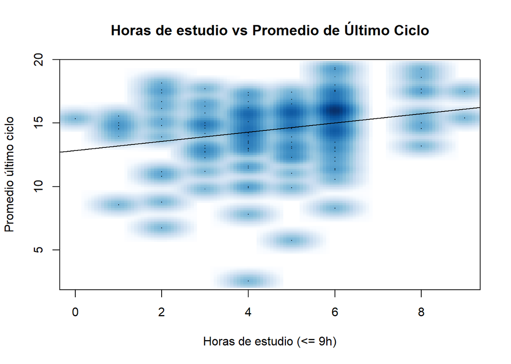

```r
#Horas de estudio vs Promedio del último ciclo (grafico) (1)
smoothScatter(HO$Prom_UltimoCiclo ~ HO$Horas_estudio,xlab="Horas de estudio (<= 9h)",ylab="Promedio último ciclo",main="Horas de estudio vs Promedio de Último Ciclo")
abline(r_1)
```

A pesar de esto, se observa cierta tendencia por ß1 = 0.3649 que indica que mientras más horas estudies (en este rango de horas), mayor será tu calificación final del ciclo a razón de 0.3649.

## 6.2 Horas de estudio (>9) vs. Promedio de último ciclo

```r
#Horas de estudio vs Promedio del último ciclo (summary) (2)
HM <- UTEC2 %>% filter(Horas_estudio > 9)
summary(HM$Horas_estudio)
```

```
##    Min. 1st Qu.  Median    Mean 3rd Qu.    Max.
##   10.00   11.00   15.00   16.94   20.00   30.00
```

```r
r_2 <- lm(HM$Prom_UltimoCiclo ~ HM$Horas_estudio)
summary(r_2)
```

```
##
## Call:
## lm(formula = HM$Prom_UltimoCiclo ~ HM$Horas_estudio)
##
## Residuals:
##     Min      1Q  Median      3Q     Max
## -4.0605 -1.3536  0.3935  1.3892  3.3293
##
## Coefficients:
##                   Estimate Std. Error t value Pr(>|t|)
## (Intercept)      15.468113   0.939958  16.456   <2e-16 ***
## HM$Horas_estudio -0.003588   0.052236  -0.069    0.946
## ---
## Signif. codes:  0 '***' 0.001 '**' 0.01 '*' 0.05 '.' 0.1 ' ' 1
##
## Residual standard error: 1.921 on 32 degrees of freedom
##   (1 observation deleted due to missingness)
## Multiple R-squared:  0.0001474,  Adjusted R-squared:  -0.0311
## F-statistic: 0.004718 on 1 and 32 DF,  p-value: 0.9457
```

Al analizar el coeficiente de determinación, nos damos cuenta que el coeficiente de variación entre las variables **Prom_UltimoCiclo** y **Horas_estudio** (para **Horas_estudio** > 9) nos da **0.0001474**, lo que quiere decir que la fuerza de dicha correlación directa es muy baja y que el modelo no predice adecuadamente la variable **Prom_UltimoCiclo**.

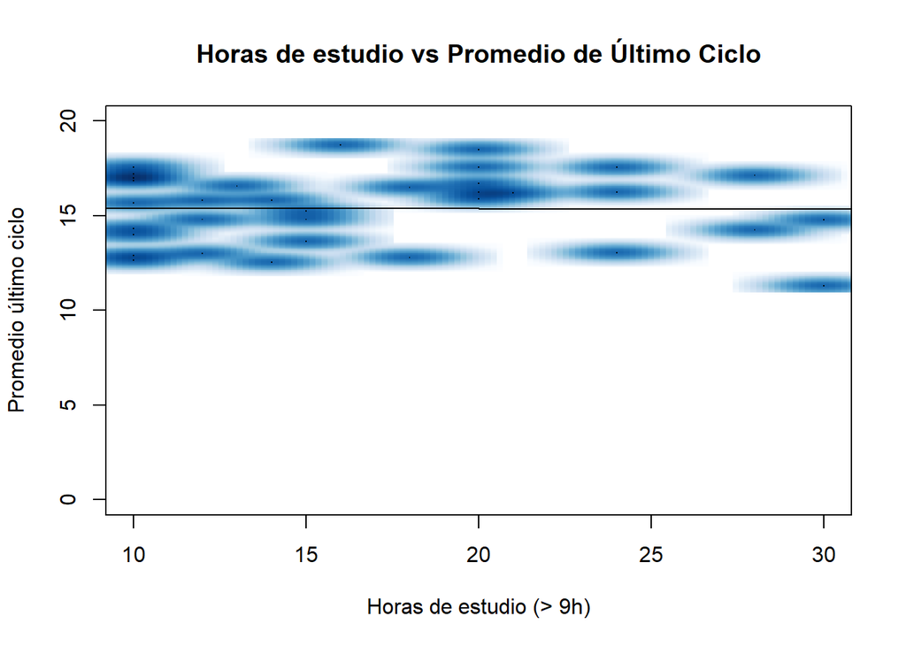

```r
#Horas de estudio vs Promedio del último ciclo (summary) (2)
smoothScatter(HM$Prom_UltimoCiclo ~ HM$Horas_estudio,ylim = c(0,20),xlab="Horas de estudio (> 9h)",ylab="Promedio último ciclo",main="Horas de estudio vs Promedio de Último Ciclo")
abline(r_2)
```

A pesar de esto, se observa cierta tendencia por ß1 = -0.003588 que indica que independientemente de cuántas horas estudies (en este rango de horas), tu calificación se mantendrá casi constante tendiendo a disminuir en -0.003588 en relación a las horas estudiadas.

## 6.3 Promedio de último ciclo vs promedio de primer ciclo

Primero filtramos la información necesaria para realizar tanto la regresión con el comando **lm()** como la predicción con el comando **predict()**.

```r
UTECP <- UTEC2 %>% select(c(20,21)) %>% na.omit(UTEC2)
x <- (UTECP$Prom_PrimerCiclo)
y <- (UTECP$Prom_UltimoCiclo)
dat = data.frame(cbind(x,y))
r_3 <- lm(y ~ x, data=dat)
summary(r_3)
```

```
##
## Call:
## lm(formula = y ~ x, data = dat)
##
## Residuals:
##     Min      1Q  Median      3Q     Max
## -4.1134 -0.9751 -0.1098  0.7548  4.5294
##
## Coefficients:
##             Estimate Std. Error t value Pr(>|t|)
## (Intercept)  4.72471    0.58173   8.122 4.93e-14 ***
## x            0.71157    0.04061  17.521  < 2e-16 ***
## ---
## Signif. codes:  0 '***' 0.001 '**' 0.01 '*' 0.05 '.' 0.1 ' ' 1
##
## Residual standard error: 1.555 on 197 degrees of freedom
## Multiple R-squared:  0.6091, Adjusted R-squared:  0.6071
## F-statistic:   307 on 1 and 197 DF,  p-value: < 2.2e-16
```

[figure not shown]

```r
smoothScatter(UTECP$Prom_UltimoCiclo ~ UTECP$Prom_PrimerCiclo,ylim = c(0,20),xlab="Promedio de último ciclo",ylab="Promedio de primer ciclo",main="Promedio de último ciclo vs promedio de primer ciclo")
abline(r_3)
```

A pesar de esto, se observa cierta tendencia por ß1 = 0.71157 y ß0 = 4.72471 que indica que mientras mayor haya sido tu calificación en el primer ciclo, mejor será en el último ciclo académico. De la misma manera, mientras peor haya sido, peor será tu calificación en el último ciclo académico.

## 6.4 Predicción de notas

Con el fin de corroborar la correlación y obtener posibles resultados en función de ciertos valores, decidimos realizar las predicciones tomando como variable independiente a **Prom_PrimerCiclo** y como variable dependiente a **Prom_UltimoCiclo**.

Primero creamos el dataframe con los valores para **Prom_PrimerCiclo** para los cuales se desea realizar la predicción y se aplica la función **predict()** con el modelo generado anteriormente **r_3** y el dataframe **pred_3**.

```r
#predicción
pred_3 <- data.frame(x = c(8,9,10,11,12,15,18))

predict(r_3, pred_3)
```

```
##        1        2        3        4        5        6        7
## 10.41725 11.12882 11.84039 12.55196 13.26352 15.39823 17.53293
```

Como respuesta al comando **predict()** nos da los valores de respuesta para **Prom_PrimerCiclo** en valores de **Prom_UltimoCiclo**, donde se puede observar que para una nota igual o menor a 8, se seguiría desaprobando el promedio ponderado en el último ciclo; sin embargo, a partir de un valor de 9 para arriba en el promedio del primer ciclo, se empezaría a aprobar el promedio del último ciclo.

```r
#gráfica de predicciones
predict(r_3)
```

```
##         1         2         3         4         5         6         7         8
## 15.163409 15.469383  9.278744 15.206103 16.109794 16.565197 15.860745 14.259718
##         9        10        11        12        13        14        15        16
## 14.878782 17.532929 15.789588 11.982701 15.967480 13.619307 17.661011 15.647275
##        17        18        19        20        21        22        23        24
## 12.886392 16.664816 16.109794 15.241681 12.231750 13.939512 16.985022 16.821361
##        25        26        27        28        29        30        31        32
## 16.714626 15.398226 14.878782 16.252107 16.003059 16.380189 16.963675 15.227450
##        33        34        35        36        37        38        39        40
## 13.476993 15.882092 14.722237 18.244497 15.113599 14.651080 16.109794 15.177640
##        41        42        43        44        45        46        47        48
## 15.078021 14.323759 15.163409 15.184756 15.092252 15.604581 16.394421 14.622617
##        49        50        51        52        53        54        55        56
## 16.109794 17.248302 15.263028 15.860745 17.817556 14.722237 12.729847 18.422389
##        57        58        59        60        61        62        63        64
## 13.476993 15.078021 13.975091 11.769231 13.213713 14.437610 12.551955 12.943318
##        65        66        67        68        69        70        71        72
## 15.775357 12.025395 13.975091 13.654885 17.532929 16.216529 15.092252 14.935707
##        73        74        75        76        77        78        79        80
## 15.362648 11.320943 13.263523 14.046247 11.648264 10.630723 16.565197 12.836582
##        81        82        83        84        85        86        87        88
## 15.263028 14.686658 17.091757 15.469383 16.180950 11.840388 15.106483 16.465578
##        89        90        91        92        93        94        95        96
## 14.864550 10.815730 16.074215 15.070905 17.155798 13.405837 15.839398 17.177145
##        97        98        99       100       101       102       103       104
## 16.280570 15.127830 14.060479 16.074215 16.821361 13.975091 15.398226 10.146857
##       105       106       107       108       109       110       111       112
## 15.398226 14.757815 13.263523 15.056674 12.551955 14.174330 16.266339 16.074215
##       113       114       115       116       117       118       119       120
## 15.163409 12.658690 16.287686 17.319459 15.006864 16.365958 11.698074 13.975091
##       121       122       123       124       125       126       127       128
##  8.816225 16.323264 13.427184 13.363142 16.465578 16.038637 14.402031 16.045753
##       129       130       131       132       133       134       135       136
## 15.149177 15.270144 10.545334 13.683348 14.828972 17.888713 14.494535 14.330874
##       137       138       139       140       141       142       143       144
## 14.181445 16.892518 13.469878 13.227945 13.035821 14.864550 16.252107 12.032511
##       145       146       147       148       149       150       151       152
## 15.682853 15.206103 15.590349 17.305227 12.765426 13.462762 14.686658 15.896323
##       153       154       155       156       157       158       159       160
## 15.398226 13.975091 11.840388 14.103173 15.704200 16.244992 14.942823 13.797199
##       161       162       163       164       165       166       167       168
## 12.694269 15.106483  9.527793 15.092252 15.988827 14.935707 14.259718 16.180950
##       169       170       171       172       173       174       175       176
## 17.212724 16.785783 11.769231 18.280075 13.847008 12.359832 16.180950 10.773036
##       177       178       179       180       181       182       183       184
## 12.765426 10.274939 15.433804 12.160593 14.757815 16.650585 15.398226 15.497845
##       185       186       187       188       189       190       191       192
## 12.295791 17.162914 13.975091 16.451346 16.615007 15.327069 13.975091 16.486925
##       193       194       195       196       197       198       199
##  6.539208 14.245486 15.789588 14.010669 12.594649 12.068089 17.262533
```

```r
predict(r_3,pred_3, se.fit = T)
```

```
## $fit
##        1        2        3        4        5        6        7
## 10.41725 11.12882 11.84039 12.55196 13.26352 15.39823 17.53293
##
## $se.fit
##         1         2         3         4         5         6         7
## 0.2698397 0.2333617 0.1984955 0.1662583 0.1384985 0.1165909 0.1941455
##
## $df
## [1] 197
##
## $residual.scale
## [1] 1.55499
```

[figure not shown]

```r
pred.w.plim <- predict(r_3,pred_3, interval = "prediction")
pred.w.clim <- predict(r_3,pred_3, interval = "confidence")
matplot(pred_3, cbind(pred.w.clim, pred.w.plim[,-1]),lty = c(1,2,2,4,4), type = "l", ylab = "Promedio del primer ciclo", xlab = "Predicción de promedio del último ciclo", main= "Predicción de notas")
```

La función de predicción que describe el modelo analizado es la siguiente:

$Y_(x)=4.724711 + 0.71157x $

## 6.5 Número de cursos reprobados vs Promedio de primer ciclo

```r
r_4 <- lm(UTEC2$N_Reprobado ~ UTEC2$Prom_PrimerCiclo)
summary(r_4)
```

```
##
## Call:
## lm(formula = UTEC2$N_Reprobado ~ UTEC2$Prom_PrimerCiclo)
##
## Residuals:
##     Min      1Q  Median      3Q     Max
## -2.8767 -0.9563 -0.3560  0.7576  5.0014
##
## Coefficients:
##                        Estimate Std. Error t value Pr(>|t|)
## (Intercept)             6.62277    0.63976  10.352  < 2e-16 ***
## UTEC2$Prom_PrimerCiclo -0.32081    0.04998  -6.419 3.26e-09 ***
## ---
## Signif. codes:  0 '***' 0.001 '**' 0.01 '*' 0.05 '.' 0.1 ' ' 1
##
## Residual standard error: 1.343 on 114 degrees of freedom
##   (90 observations deleted due to missingness)
## Multiple R-squared:  0.2655, Adjusted R-squared:  0.259
## F-statistic: 41.21 on 1 and 114 DF,  p-value: 3.256e-09
```

El valor de R nos indica que no existe un buen ajuste del modelo lineal de los datos, este es de *0.265*.

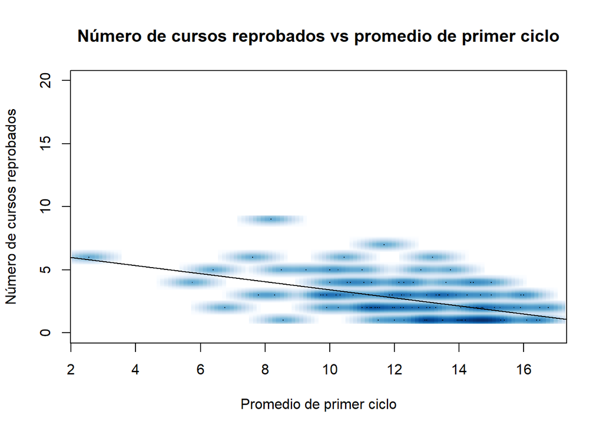

```r
smoothScatter(UTEC2$N_Reprobado ~ UTEC2$Prom_PrimerCiclo,ylim = c(0,20),xlab="Promedio de primer ciclo",ylab="Número de cursos reprobados",main="Número de cursos reprobados vs promedio de primer ciclo")
abline(r_4)
```